# Q1)Interpret the data and the variables

- data are individual pieces of factual information recorded and used for the purpose of analysis. It is the raw information from which statistics are created
- A variable is any characteristics, number, or quantity that can be measured or counted

# Q2)Interpret why you selected that dataset and what is the message you are planning to give to your audience

```
import numpy as np
import pandas as pd
import matplotlib.pyplot as plt
from matplotlib.patches import Circle
%matplotlib inline
```

```
df=pd.read_csv(r"C:\Users\0774051680\Downloads\Salaries.csv")

df.set_index(df['Id'],inplace=True)
df.drop('Notes',axis=1,inplace=True)
df
```

| Id | Id | EmployeeName | JobTitle | BasePay | OvertimePay | OtherPay | Benefits | TotalPay | TotalPayBenefits | Year | Agency | Status |
| --- | --- | --- | --- | --- | --- | --- | --- | --- | --- | --- | --- | --- |
| 1 | 1 | NATHANIEL FORD | GENERAL MANAGER-METROPOLITAN TRANSIT AUTHORITY | 167411.18 | 0.00 | 400184.25 | NaN | 567595.43 | 567595.43 | 2011 | San Francisco | NaN |
| 2 | 2 | GARY JIMENEZ | CAPTAIN III (POLICE DEPARTMENT) | 155966.02 | 245131.88 | 137811.38 | NaN | 538909.28 | 538909.28 | 2011 | San Francisco | NaN |
| 3 | 3 | ALBERT PARDINI | CAPTAIN III (POLICE DEPARTMENT) | 212739.13 | 106088.18 | 16452.60 | NaN | 335279.91 | 335279.91 | 2011 | San Francisco | NaN |
| 4 | 4 | CHRISTOPHER CHONG | WIRE ROPE CABLE MAINTENANCE MECHANIC | 77916.00 | 56120.71 | 198306.90 | NaN | 332343.61 | 332343.61 | 2011 | San Francisco | NaN |
| 5 | 5 | PATRICK GARDNER | DEPUTY CHIEF OF DEPARTMENT,(FIRE DEPARTMENT) | 134401.60 | 9737.00 | 182234.59 | NaN | 326373.19 | 326373.19 | 2011 | San Francisco | NaN |
| ... | ... | ... | ... | ... | ... | ... | ... | ... | ... | ... | ... | ... |
| 148650 | 148650 | Roy I Tillery | Custodian | 0.00 | 0.00 | 0.00 | 0.0 | 0.00 | 0.00 | 2014 | San Francisco | NaN |
| 148651 | 148651 | Not provided | Not provided | NaN | NaN | NaN | NaN | 0.00 | 0.00 | 2014 | San Francisco | NaN |
| 148652 | 148652 | Not provided | Not provided | NaN | NaN | NaN | NaN | 0.00 | 0.00 | 2014 | San Francisco | NaN |
| 148653 | 148653 | Not provided | Not provided | NaN | NaN | NaN | NaN | 0.00 | 0.00 | 2014 | San Francisco | NaN |
| 148654 | 148654 | Joe Lopez | Counselor, Log Cabin Ranch | 0.00 | 0.00 | -618.13 | 0.0 | -618.13 | -618.13 | 2014 | San Francisco | NaN |

148654 rows × 12 columns

**Above are the details of the 148654 employees of the San Francisco Company. we included their basic salary,overtime salary,bonus salary and their job respect to 2011,2012,2013,1014.from this sheet we can find who gets highest salary,how many jobs are here,etc**

# Q3)Using scatter plots to explain relationship

```
x=df['BasePay'].head(200)
y=df['OtherPay'].head(200)
plt.scatter(x,y)
plt.xlabel("BasePay")
plt.ylabel("OtherPay")
plt.title('BasePay vs OtherPay ')
plt.text(167411.18,400184.25,'outlier',va='center')
plt.gca().margins(0.1)
cir=Circle((167411.18,400184.25),0.5,color='red',fill=False,zorder=10)
plt.gca().add_patch(cir)
plt.show()
```

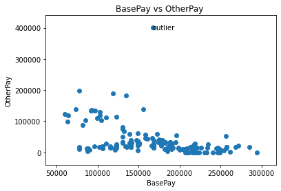

- from this scatter plot we can say there are no relationship between base pay and other pay because in this graph correlation value is very low(r=0.285)

|  | BasePay | OtherPay |
| --- | --- | --- |
| BasePay | 1.000000 | 0.285655 |
| OtherPay | 0.285655 | 1.000000 |

# Q4)Using line plots to explain a time series or relationship

```
groupby_yr=df.copy().groupby('Year')['BasePay'].mean()

yr='2011 2012 2013 2014'.split()
plt.plot(yr,groupby_yr);
plt.ylabel("mean of base pay")
plt.xlabel('years')
plt.title('mean of the years')
plt.show()
```

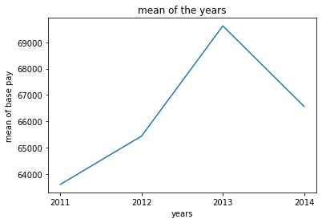

# Q5)Using Pie Plot to explain a categorical variable with a numerical variable.

```
max_job=df['JobTitle'].value_counts().head()
print(max_job)
lbls=['Transit Operator','Special Nurse','Registered Nurse','public Svc Aide-Public Works','Police Officer 3']
x=[7036,4389,3736,2518,2421]

plt.pie(x,labels=lbls,shadow=True,autopct='%1.1f%%')
plt.title('top 5 maximum number of job');
plt.show()
```

```
Transit Operator                7036
Special Nurse                   4389
Registered Nurse                3736
Public Svc Aide-Public Works    2518
Police Officer 3                2421
Name: JobTitle, dtype: int64
```

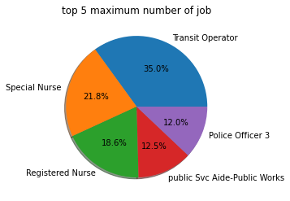

Here i have drawn a pie chart of top 5 counted jobs in san fransisco company. In that, Transit Operator is high percentage and Police Officer 3 has low percentage and number of employee

# Q6)Using Bar Plot to explain a categorical variable with a numerical variable

```
top_sal=df.copy().sort_values('TotalPayBenefits',ascending=False)
```

```
x=top_sal['JobTitle'].head()
y=top_sal['TotalPayBenefits'].head()
plt.bar(x,y);
plt.xticks(rotation=90);
plt.title('top salaries job in San Francisco')
plt.xlabel('JobTitle')
plt.ylabel('salaries')
plt.show()
```

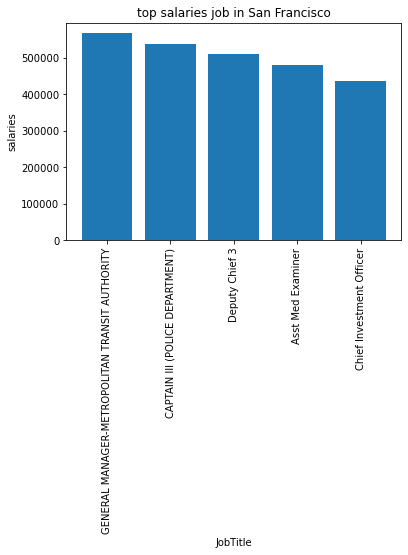

Here I have drawn a bar chat for finding which job has highst payable.I have drawn top 5 highest payable job in bar chart. the highest payable person in GENERAL MANAGER-METROPOLITAN TRANSIT AUTHORITY.

# Q7)Using insets or subplots of matplotlib at least one time in any of your charts

```
fig,(ax1, ax2) = plt.subplots(1, 2)
x=df['BasePay']
y=['OtherPay','TotalPay']
ax1.plot(x,df[y[0]])
ax1.set_title('BasePay vs OtherPay')
ax1.set_xlabel('basepay')
ax1.set_ylabel('OtherPay')
ax2.plot(x,df[y[1]])
ax2.set_title('BasePay vs TotalPay')
ax2.set_xlabel('basepay')
ax2.set_ylabel('TotalPay')

fig.tight_layout(pad = 1)
plt.show()
```

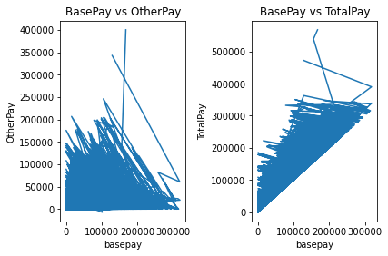

# Q8) Annotate any of the above graph using text and patch. (Minimum one patch and minimum one Text)

- *see question number 3*

# Q9) Use at least one 3D chart either line scatter or bar plot

```
groupby_yr=df.groupby(by='Year').mean()
```

```
mean_=groupby_yr[['BasePay','OvertimePay','OtherPay','TotalPayBenefits']]
```

```
from mpl_toolkits import mplot3d
fig = plt.figure(figsize=(8, 10))
ax = plt.axes(projection="3d")
pivot_ = mean_.pivot_table(index='Year')




rows_, columns_= pivot_.shape

xpos = np.arange(0, rows_, 1)
ypos = np.arange(0, columns_, 1)

xpos, ypos = np.meshgrid(xpos, ypos)
xpos = xpos.flatten()
ypos = ypos.flatten()
zpos = np.zeros(rows_*columns_)
width_, lenght_ = 0.25, 0.25
x_val = width_*np.ones(rows_*columns_)
y_val = lenght_*np.ones(rows_*columns_)
z_val = pivot_.values.flatten()
colors = ['red', 'blue', 'brown', 'green']*columns_
ax.bar3d(xpos, ypos, zpos, x_val, y_val, z_val,color=colors)
ax.w_yaxis.set_ticklabels(['0', '2011', ' ', '2012', ' ', '2013', ' ', '2014']);
ax.w_xaxis.set_ticklabels([0,0,'BasePay',' ', 'OvertimePay',' ', 'OtherPay','TotalPayBenefits']);
```

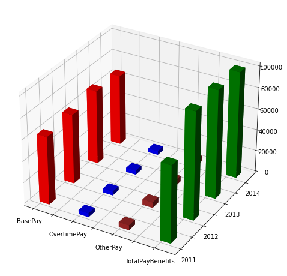

```
ax.view_init(60,95)
fig
```

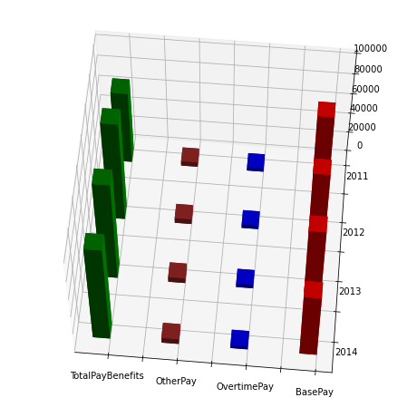

# Q10) Overall Idea conveyed to audience using the charts presented earlier with respect to objective you defined in Question 2.

- from this graph these calculate each year mean of the salary and which person get higher salary and which job has maximum are here and relationship between various salaries and we can manipulate data what we want.